# Spark EDA — Thanh M. Brown

Thanh M. Brown

Data Scientist · Bioinformatics · ML · Health Data

Project 04 · Big Data · PySpark

Income Distribution & Healthcare Spending Analysis

PySpark Big Data Health Data EDA Python Snowflake

# Income Distribution and Healthcare Spending Analysis

# 1. Project Overview

This analysis explores the relationship between **income levels and healthcare spending** using a large synthetic healthcare dataset.

The objective is to understand how healthcare expenditures vary across income groups and identify patterns that may reflect differences in access to care, healthcare utilization, or preventive health behavior.

The dataset contains over **1.2 million patient records**, making it suitable for distributed processing using **Apache Spark**.

## 1a. Business Questions

Healthcare spending varies significantly across populations, but the relationship between **income level and healthcare utilization** is not always straightforward.

Key questions explored in this analysis:

1. How is income distributed across the population?
2. Do higher income groups spend more on healthcare?
3. At what income level does healthcare spending peak?
4. Are there demographic differences in healthcare expenses?

Understanding these patterns can help inform:

- healthcare policy planning
- insurance risk modeling
- population health management

# 2. Dataset Overview

> **Insight:**  
> The dataset shows a strong right-skewed distribution.

## 2b. Analytical Insight

Healthcare spending does not increase linearly with income. While spending rises rapidly between the \$15K – \$70K income brackets, it plateaus and eventually declines among higher-income populations.

This pattern may suggest that middle-income populations experience the highest healthcare utilization, whereas higher-income individuals benefit from preventive care and better health management.

## 2c. Hypothesis for Further Analysis

Potential factors influencing the pattern:

- Insurance coverage differences
- Preventive care access
- Age distribution across income brackets
- Chronic disease prevalence

# 3. Data Engineering (Spark)

## Data Processing Pipeline

The analysis follows a distributed data processing workflow using Apache Spark.

Pipeline steps:

1. Data ingestion from Snowflake dataset
2. Schema inspection and data validation
3. Distributed aggregation using Spark SQL
4. Feature engineering (income brackets)
5. Statistical analysis
6. Visualization using Pandas + Matplotlib

Spark was used for large-scale data processing, while smaller aggregated datasets were converted to Pandas for visualization.

This hybrid workflow enables scalable processing while maintaining flexible analysis capabilities.

```python
# Import SparkSession
from pyspark.sql import SparkSession

# Create SparkSession
spark = SparkSession.builder \
      .master("local[1]") \
      .appName("SparkByExamples.com") \
      .getOrCreate()

# Create RDD from external Data source
rdd2 = spark.sparkContext.textFile("/path/test.txt")
```

[output not shown]

```python
data_path = '/Users/thanhbrown/Home/work_portfolio/healthcare_spark/data/raw/warming_up.csv'
data_frame = (
        spark.read
        .option("header", True)
        .option("inferSchema", True)
        .csv(data_path)
    )
```

```python
spark.conf.set('spark.sql.repl.eagerEval.enabled', True)

data_frame
```

| PATIENT_ID | BIRTHDATE | DEATHDATE | SSN | DRIVERS | PASSPORT | PREFIX | FIRST | MIDDLE | LAST | SUFFIX | MAIDEN | MARITAL | RACE | ETHNICITY | GENDER | BIRTHPLACE | ADDRESS | CITY | STATE | COUNTY | FIPS | ZIP | LAT | LON | HEALTHCARE_EXPENSES | HEALTHCARE_COVERAGE | INCOME | SYNTHEA_CITY |
| --- | --- | --- | --- | --- | --- | --- | --- | --- | --- | --- | --- | --- | --- | --- | --- | --- | --- | --- | --- | --- | --- | --- | --- | --- | --- | --- | --- | --- |
| 1640106 | 2000-10-04 | NULL | 999-37-5169 | S99927567 | X33172632X | Ms. | Eloisa | María del Carmen | León | NULL | NULL | NULL | white | hispanic | F | Wesley Saint And... | 557 Abbott Lane | Austin | Texas | Hays County | 48453 | 78725 | 30.354726579225414 | -97.73422750216807 | 75583.97 | 294119.98 | 600051 | AUSTIN |
| 1640107 | 2012-02-10 | NULL | 999-44-7325 | NULL | NULL | NULL | Maryam | Danita | Tillman | NULL | NULL | NULL | white | nonhispanic | F | Longview Texas US | 722 Fadel Key Sui... | Austin | Texas | Hays County | 48453 | 78732 | 30.241189796621992 | -97.67758852990734 | 43459.33 | 16700.37 | 48653 | AUSTIN |
| 1640108 | 1963-08-11 | NULL | 999-68-4600 | S99983898 | X57933561X | Mr. | Shad | NULL | Pagac | NULL | NULL | S | white | hispanic | M | San Antonio Texa... | 442 Schmidt Throu... | Austin | Texas | Hays County | 48453 | 78758 | 30.391158191525708 | -97.82603275334445 | 430034.9 | 284638.58 | 8390 | AUSTIN |
| 1640109 | 2003-04-20 | NULL | 999-18-7911 | S99910290 | X22386013X | Mr. | Alex | NULL | Hammes | NULL | NULL | NULL | white | hispanic | M | Big Spring Texas... | 433 Becker Passag... | Austin | Texas | Hays County | 48453 | 78744 | 30.448291322845034 | -97.88521095196566 | 7751.63 | 67354.64 | 15977 | AUSTIN |
| 1640110 | 1951-12-23 | NULL | 999-67-9744 | S99990121 | X11642889X | Mrs. | Cherish | Shakita | Stoltenberg | NULL | Monahan | D | white | nonhispanic | F | Irving Texas US | 697 Wiza Crossing | Austin | Texas | Hays County | 48453 | 78749 | 30.5354363419989 | -97.8646393237985 | 684121.28 | 130648.4 | 99273 | AUSTIN |
| 1640111 | 2014-04-13 | NULL | 999-16-4648 | NULL | NULL | NULL | Darren | Leon | Dietrich | NULL | NULL | NULL | white | nonhispanic | M | Lubbock Texas US | 394 Hayes Hollow ... | Austin | Texas | Hays County | 48453 | 78739 | 30.129846173226507 | -97.57234941245392 | 23805.47 | 0.0 | 94919 | AUSTIN |
| 1640112 | 1980-11-04 | NULL | 999-89-2304 | S99929484 | X84264157X | Mr. | Palmer | Hyman | Sipes | NULL | NULL | D | white | nonhispanic | M | Hewitt Texas US | 827 Krajcik Union... | Austin | Texas | Hays County | 48453 | 78741 | 30.243705989128614 | -97.68952854520568 | 122641.66 | 36055.11 | 954499 | AUSTIN |
| 1640113 | 1982-07-19 | NULL | 999-80-7707 | S99970819 | X64509957X | Mr. | Daryl | Teddy | Ryan | NULL | NULL | D | white | nonhispanic | M | Houston Texas US | 357 Davis Esplanade | Austin | Texas | Hays County | 48491 | 78717 | 30.34413813354928 | -97.93154202232147 | 145434.53 | 1092025.1 | 8978 | AUSTIN |
| 1640114 | 1994-04-26 | NULL | 999-43-5125 | S99957739 | X68419579X | Mrs. | Débora | Francisca | Madera | NULL | Toro | M | white | hispanic | F | Carolina Puerto ... | 503 Keebler Cente... | Austin | Texas | Hays County | 48453 | 78741 | 30.37585635437581 | -97.55014443141285 | 97101.96 | 612425.37 | 13729 | AUSTIN |
| 1640115 | 1963-08-13 | NULL | 999-93-6364 | S99951081 | X66961424X | Mrs. | Jeanne | Chin | Hermiston | NULL | Murphy | M | white | nonhispanic | F | Sugar Land Texas... | 692 Kuhlman Meadow | Austin | Texas | Hays County | 48453 | 78750 | 30.30485682126074 | -97.64607331883383 | 229508.53 | 671061.29 | 18485 | AUSTIN |
| 1640116 | 1981-12-08 | NULL | 999-57-5488 | S99935062 | X9142516X | Mrs. | Alicia | NULL | Casas | NULL | Fernández | W | white | hispanic | F | San Juan Puerto ... | 138 Stokes Burg U... | Austin | Texas | Hays County | 48453 | 78660 | 30.3317735118376 | -97.77549016248436 | 306258.91 | 451376.93 | 2803 | AUSTIN |
| 1640117 | 2005-10-02 | NULL | 999-99-8126 | S99927805 | NULL | Mr. | Luis | Manuel | Olivares | NULL | NULL | NULL | black | hispanic | M | Juarez Chihuahua... | 138 Hammes Ferry ... | Austin | Texas | Hays County | 48453 | 78750 | 30.410658199513644 | -97.79402405988824 | 57614.8 | 197611.58 | 79641 | AUSTIN |
| 1640118 | 1991-04-03 | NULL | 999-10-4433 | S99956308 | X89460230X | Mr. | Dennis | Arnold | Bode | NULL | NULL | M | black | nonhispanic | M | Arlington Texas US | 803 Schuppe Lodge | Austin | Texas | Hays County | 48453 | 78744 | 30.28485521668174 | -97.82801447687807 | 65199.91 | 550518.32 | 996 | AUSTIN |
| 1640119 | 1993-08-10 | NULL | 999-42-6132 | S99975433 | X33504910X | Mr. | Howard | Ignacio | Abbott | NULL | NULL | M | white | hispanic | M | Dallas Texas US | 864 Waelchi Camp ... | Austin | Texas | Hays County | 48453 | 78734 | 30.186529529252535 | -97.75063376599643 | 65535.25 | 15874.07 | 49427 | AUSTIN |
| 1640120 | 2020-03-29 | NULL | 999-22-3187 | NULL | NULL | NULL | Roderick | Derick | Bosco | NULL | NULL | NULL | white | nonhispanic | M | Houston Texas US | 967 Daugherty Ville | Austin | Texas | Hays County | 48453 | 78742 | 30.541822801406493 | -97.67857620480662 | 9712.89 | 0.0 | 59358 | AUSTIN |
| 1640121 | 1971-07-03 | NULL | 999-41-3265 | S99969956 | X38591251X | Mr. | Arlen | Lawerence | Bailey | NULL | NULL | M | white | hispanic | M | Edinburg Texas US | 1066 Boyer Bridge | Austin | Texas | Hays County | 48453 | 78723 | 30.17923179171047 | -97.7836328356483 | 163553.29 | 57088.71 | 36658 | AUSTIN |
| 1640122 | 1983-10-24 | NULL | 999-40-9630 | S99973435 | X74977147X | Mr. | Dylan | Leandro | Hayes | NULL | NULL | S | white | nonhispanic | M | Amarillo Texas US | 662 Bruen Dale | Austin | Texas | Hays County | 48209 | 78610 | 30.266042712591933 | -97.70404670044297 | 632187.87 | 0.0 | 81708 | AUSTIN |
| 1640123 | 1930-05-28 | 2002-04-23 | 999-37-6544 | S99962206 | X194625X | Mr. | César | Bernardo | Matos | NULL | NULL | S | white | hispanic | M | Wesley Saint And... | 406 Weber Burg | Austin | Texas | Hays County | 48453 | 78741 | 30.10035672282173 | -97.5711182110766 | 105484.65 | 1757252.01 | 201309 | AUSTIN |
| 1640124 | 2003-01-11 | NULL | 999-16-5612 | S99946585 | X75431317X | Ms. | Grace | Kecia | Considine | NULL | NULL | NULL | white | nonhispanic | F | Belton Texas US | 871 Kshlerin Spur... | Austin | Texas | Hays County | 48453 | 78701 | 30.299539751127124 | -97.67210058669058 | 88679.25 | 49575.44 | 40877 | AUSTIN |
| 1640125 | 1964-11-05 | NULL | 999-23-1335 | S99955769 | X35985558X | Mrs. | Anna | Ivy | Herman | NULL | Ratke | M | white | nonhispanic | F | Chandler Texas US | 796 Bogisich Well... | Austin | Texas | Hays County | 48453 | 78730 | 30.357610383913563 | -97.74642132691518 | 1335250.57 | 79548.51 | 62100 | AUSTIN |

only showing top 20 rows

```python
data_frame.show(2, vertical=True)
```

```
-RECORD 0-----------------------------------
 PATIENT_ID          | 1640106
 BIRTHDATE           | 2000-10-04
 DEATHDATE           | NULL
 SSN                 | 999-37-5169
 DRIVERS             | S99927567
 PASSPORT            | X33172632X
 PREFIX              | Ms.
 FIRST               | Eloisa
 MIDDLE              | María del Carmen
 LAST                | León
 SUFFIX              | NULL
 MAIDEN              | NULL
 MARITAL             | NULL
 RACE                | white
 ETHNICITY           | hispanic
 GENDER              | F
 BIRTHPLACE          | Wesley  Saint And...
 ADDRESS             | 557 Abbott Lane
 CITY                | Austin
 STATE               | Texas
 COUNTY              | Hays County
 FIPS                | 48453
 ZIP                 | 78725
 LAT                 | 30.354726579225414
 LON                 | -97.73422750216807
 HEALTHCARE_EXPENSES | 75583.97
 HEALTHCARE_COVERAGE | 294119.98
 INCOME              | 600051
 SYNTHEA_CITY        | AUSTIN
-RECORD 1-----------------------------------
 PATIENT_ID          | 1640107
 BIRTHDATE           | 2012-02-10
 DEATHDATE           | NULL
 SSN                 | 999-44-7325
 DRIVERS             | NULL
 PASSPORT            | NULL
 PREFIX              | NULL
 FIRST               | Maryam
 MIDDLE              | Danita
 LAST                | Tillman
 SUFFIX              | NULL
 MAIDEN              | NULL
 MARITAL             | NULL
 RACE                | white
 ETHNICITY           | nonhispanic
 GENDER              | F
 BIRTHPLACE          | Longview  Texas  US
 ADDRESS             | 722 Fadel Key Sui...
 CITY                | Austin
 STATE               | Texas
 COUNTY              | Hays County
 FIPS                | 48453
 ZIP                 | 78732
 LAT                 | 30.241189796621992
 LON                 | -97.67758852990734
 HEALTHCARE_EXPENSES | 43459.33
 HEALTHCARE_COVERAGE | 16700.37
 INCOME              | 48653
 SYNTHEA_CITY        | AUSTIN
only showing top 2 rows
```

```python
## General stats
```

```python
# data_frame.groupBy("GENDER").agg(F.countDistinct("id").alias("unique_id_count"))
# data_frame.select("GENDER").distinct().count()

from pyspark.sql import functions as F
from pyspark.sql.functions import col, count, sum
# from pyspark.sql.window import Window

def count_unique_and_percent(value):

    counts = data_frame.groupBy(value).count()

    total = data_frame.count()

    result = counts.withColumn(
        "percent",
        col("count") / total * 100
    )

    result.show()

count_unique_and_percent("RACE")
```

```
[Stage 10:======================================>                   (2 + 1) / 3]
```

```
+--------+------+-------------------+
|    RACE| count|            percent|
+--------+------+-------------------+
|   asian|108267|  7.615555380485856|
|   other| 16577|  1.166034540001238|
|   white|978825|  68.85104413444603|
|   black|294507|  20.71577090379107|
|  native|  6960|0.48956991002042693|
|hawaiian| 16520|  1.162025131255381|
+--------+------+-------------------+
```

```python
count_unique_and_percent("ETHNICITY")
```

```
[Stage 16:======================================>                   (2 + 1) / 3]
```

```
+-----------+-------+------------------+
|  ETHNICITY|  count|           percent|
+-----------+-------+------------------+
|nonhispanic|1206908| 84.89451737973181|
|   hispanic| 214748|15.105482620268193|
+-----------+-------+------------------+
```

```python
count_unique_and_percent("GENDER")
```

```
[Stage 22:======================================>                   (2 + 1) / 3]
```

```
+------+------+------------------+
|GENDER| count|           percent|
+------+------+------------------+
|     F|713363|50.178313178434166|
|     M|708293|49.821686821565834|
+------+------+------------------+
```

# 4. Income Distribution Analysis

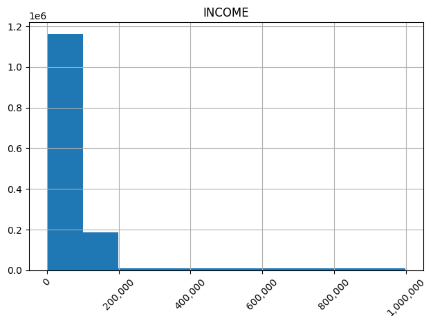

```python
import matplotlib.pyplot as plt
import matplotlib.ticker as ticker

income= (data_frame.select("INCOME").
                    toPandas()
            )


fig, ax = plt.subplots()
income.hist(ax=ax)
ax.xaxis.set_major_formatter(ticker.FuncFormatter(lambda x, _: f'{x:,.0f}'))
plt.xticks(rotation=45)  # Rotate so numbers don't overlap
plt.tight_layout()
plt.show()
```

**Interpretation**:

The Y-axis shows frequency (count) — the number of records/rows in the dataset that fall within each income bin. The 1e6 multiplier at the top means the values are in millions, so:

- The tallest bar (~1.17) = approximately 1,170,000 records with income between $0–$100K
- The second bar (~0.19) = approximately 190,000 records with income between $100K–$200K
- All remaining bars are nearly flat = very few records with income above $200K

What the shape tells you

- This is a classic right-skewed (positive skew) distribution, which is very typical for income data:
- The vast majority of your population earns under \$100k
- A smaller but notable group earns \$100k – \$200k
- A tiny minority (outliers) earn up to \$1,000,000

```python
data_frame.select("INCOME").summary("count",  "min", "25%","mean","50%", "stddev", "75%", "max").show()
```

```
[Stage 26:===================>                                      (1 + 1) / 3]
```

```
+-------+------------------+
|summary|            INCOME|
+-------+------------------+
|  count|           1421656|
|    min|                 0|
|    25%|             17149|
|   mean| 78416.96058680862|
|    50%|             39850|
| stddev|138024.94543862357|
|    75%|             81096|
|    max|            998949|
+-------+------------------+
```

Note: there's a huge difference in mean and median (or 50%). This is because mean was bias towards outliers (which present in this case).

```python
income["INCOME"].quantile([0.1, 0.25, 0.5, 0.75, 0.9, 0.99])
```

```
0.10      6884.00
0.25     17150.00
0.50     39855.00
0.75     81110.00
0.90    144760.50
0.99    840170.45
Name: INCOME, dtype: float64
```

### Log transformation of x-axis

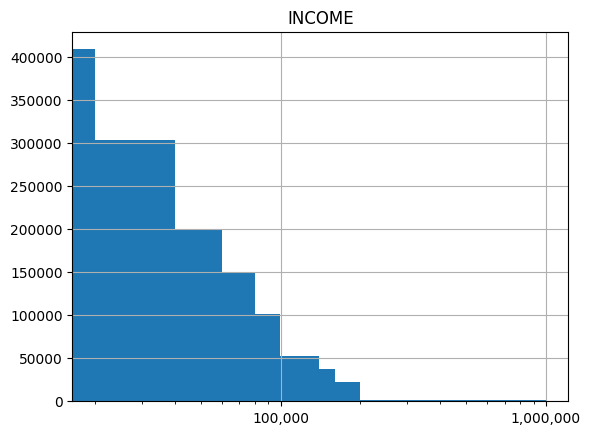

```python
fig, ax = plt.subplots()
income.hist(ax=ax, bins=50)
ax.set_xscale('log')
ax.xaxis.set_major_formatter(ticker.FuncFormatter(lambda x, _: f'{x:,.0f}'))
plt.show()
```

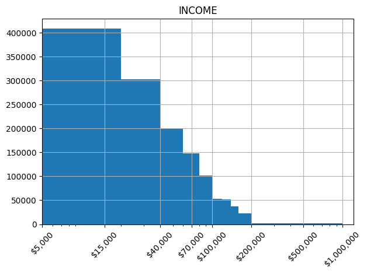

```python
import matplotlib.ticker as ticker

fig, ax = plt.subplots()
income.hist(ax=ax, bins=50)
ax.set_xscale('log')

# Explicitly define the tick positions you want to show
tick_positions = [5000, 15000, 40000, 70000, 100000, 200000, 500000, 1000000]
ax.set_xticks(tick_positions)

# Format them with commas and a $ sign
ax.xaxis.set_major_formatter(ticker.FuncFormatter(lambda x, _: f'${x:,.0f}'))

plt.xticks(rotation=45)  # rotate so labels don't overlap
plt.tight_layout()       # prevent labels from being cut off
plt.show()
```

- *Interpretation*:
  - From reading the bars, we observe:

> **Insight:**  
> The income distribution is **strongly right-skewed**, with the majority of individuals earning under $40K.

> ⚠️ **Data Note:**  
> The $500K+ category contains extreme outliers that may distort mean income statistics.

This shape — a straight declining line on a log x-axis — is actually close to a Pareto distribution, which is the classic mathematical model for income and wealth data in real-world populations. It basically confirms: the fewer people, the higher the income.

### Dataset Snapshot

# 5. Gender Analysis

## Summary stats a quick lense

```python
df = data_frame.select("GENDER", "INCOME").toPandas()
df.groupby("GENDER")["INCOME"].describe()
```

| GENDER | count | mean | std | min | 25% | 50% | 75% | max |
| --- | --- | --- | --- | --- | --- | --- | --- | --- |
| F | 713363.0 | 78167.985528 | 138061.080894 | 0.0 | 17037.0 | 39635.0 | 80755.5 | 998862.0 |
| M | 708293.0 | 78667.717823 | 137988.185153 | 0.0 | 17258.0 | 40087.0 | 81479.0 | 998949.0 |

## Viz distribution

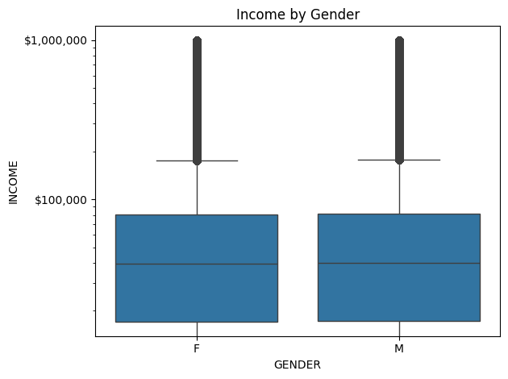

```python
import seaborn as sns

fig, ax = plt.subplots()
sns.boxplot(data=df, x="GENDER", y="INCOME", ax=ax)
ax.set_yscale('log')
ax.yaxis.set_major_formatter(ticker.FuncFormatter(lambda x, _: f'${x:,.0f}'))
plt.title("Income by Gender")
plt.tight_layout()
plt.show()
```

The box plot shows you median, spread, and outliers per gender at a glance. It seems that there's not much difference in median. Also notice lots of outliers for both genders

## Statistical test: is the difference significant?

```python
from scipy import stats

male   = df[df["GENDER"] == "M"]["INCOME"].dropna()
female = df[df["GENDER"] == "F"]["INCOME"].dropna()

t_stat, p_value = stats.mannwhitneyu(male, female, alternative='two-sided')
print(f"p-value: {p_value}")
```

```
p-value: 2.3758734348749904e-07
```

Use **Mann-Whitney U** (not a t-test) because income is skewed, not normally distributed.

| p-value | Meaning |
| --- | --- |
| `< 0.05` | Statistically significant difference in income between genders |
| `>= 0.05` | No statistically significant difference found |

# 6. Income vs Healthcare Spending

This is now a relationship between **two continuous variables**, so the approach is different from the gender comparison

## Summary stats

```python
df = data_frame.select("INCOME", "HEALTHCARE_EXPENSES").toPandas()

# Pearson (linear) or Spearman (non-linear, better for skewed data)
print(df[["INCOME", "HEALTHCARE_EXPENSES"]].corr(method='spearman'))
```

```
                       INCOME  HEALTHCARE_EXPENSES
INCOME               1.000000             0.462926
HEALTHCARE_EXPENSES  0.462926             1.000000
```

## Viz

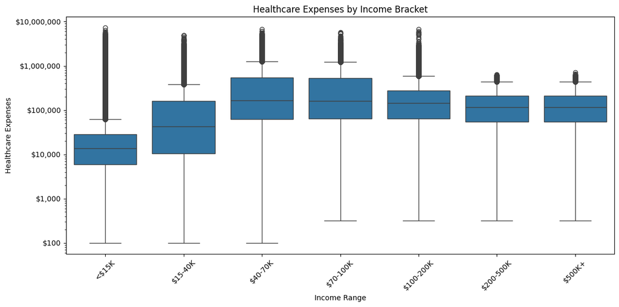

```python
import seaborn as sns
import numpy as np
import pandas as pd

# Create income brackets
df["INCOME_BUCKET"] = pd.cut(df["INCOME"],
    bins=[0, 15000, 40000, 70000, 100000, 200000, 500000, np.inf],
    labels=["<$15K", "$15-40K", "$40-70K", "$70-100K", "$100-200K", "$200-500K", "$500K+"]
)

fig, ax = plt.subplots(figsize=(12, 6))
sns.boxplot(data=df, x="INCOME_BUCKET", y="HEALTHCARE_EXPENSES", ax=ax)
ax.set_yscale('log')
ax.yaxis.set_major_formatter(ticker.FuncFormatter(lambda x, _: f'${x:,.0f}'))
plt.xlabel("Income Range")
plt.ylabel("Healthcare Expenses")
plt.title("Healthcare Expenses by Income Bracket")
plt.xticks(rotation=45)
plt.tight_layout()
plt.show()
```

# 7. Income Distribution Summary

**Key Finding**: Healthcare Expenses RISE with Income (up to a point)

| Income Bracket | Median Healthcare Expense | Observation |
| --- | --- | --- |
| <\$15k | \$12,000 | Very limited spending |
| \$15–40k | \$40,000 | Significant jump |
| \$40–70k | \$175,000 | Another large jump |
| \$70–100k | \$175,000 | Similar to previous bracket |
| \$100–200k | \$150,000 | Slight plateau |
| \$200–500k | \$110,000 | Starts declining |
| \$500k+ | \$110,000 | Similar to $200–500K |

**Important Patterns to Notice**

> **Insight 1 — Healthcare spending rises sharply with income initially**  
> Lower-income populations (<$40K) show much lower median healthcare expenses, likely reflecting:
> - Reduced access to care
> - Delayed or deferred treatments
> - Affordability constraints

> **Insight 2 - The big jump from <$15K to \$15–40K**

> The median nearly triples between these two groups. The lowest earners spend dramatically less on healthcare — likely due to inability to afford care, not because they need it less.

> **Insight 3 — Peak spending occurs in middle-income groups (\$40K –\$100K)**  
> Healthcare expenses increase dramatically and plateau around **\$175K**, suggesting:
> - Higher healthcare utilization once financial barriers decrease
> - Greater access to medical services

> **Insight 4 - Plateau and slight decline after \$70K**

> Healthcare expenses don't keep rising indefinitely. After \$70–100K, the median flattens then slightly drops — suggesting:
> - high earners may be more efficient or healthier overall.

> **Insight 5 — Spending declines in higher-income brackets**  
> Income groups above $200K show lower median healthcare expenses, which may reflect:
> - Better preventive care
> - Healthier lifestyles
> - Superior insurance coverage

> **Insight 6 - Massive outliers in every bracket**

**Bottom Line**

Income and healthcare expenses are positively correlated up to ~ \$70–100K, then level off. The biggest barrier is at the bottom — the <$15K group spends far less, likely reflecting access and affordability constraints rather than better health.

# 8. Final Takeaways

> Although low-income populations represent the largest group in the dataset, their healthcare spending remains relatively low.

> The majority of healthcare expenditures appear concentrated in middle-income brackets ($40K–$100K), where healthcare utilization peaks.

> This finding may reflect increased healthcare access through employer-provided insurance and higher treatment utilization among middle-income individuals.

## Jupyter Notebook Environment

Tools and libraries used in this project:

- Python 3.12
- Apache Spark (PySpark)
- Pandas
- NumPy
- Matplotlib / Seaborn
- Jupyter Notebook

Infrastructure:

- Local Spark environment
- Dataset sourced from Snowflake Marketplace